# Assignment 3: Data Visualization

## Introduction

The state with the lowest AAPI prison pop. is WY and the highest is CA

The state with the lowest native prison pop. from age 15 to 64 is DC and the highest is OK

The Columbia County has the highest metro area

### Summary information

This assignment focuses on the prison racism population in the United States by using the incarceration_trends.csv dataframe(2018). I want to analyze the population of the different races in jail and its relation to particular individual regions.

## Trends over time chart

For the first chart, I choose Black and White criminal population in CA to compare how those two values changing from 2009 to 2018. In this chart, we can see that the total white jail population is much higher than the total black population. This chart also emerges the flow of both Black and White jail population are really similar, so when the total_white goes down then total_black also goes down.

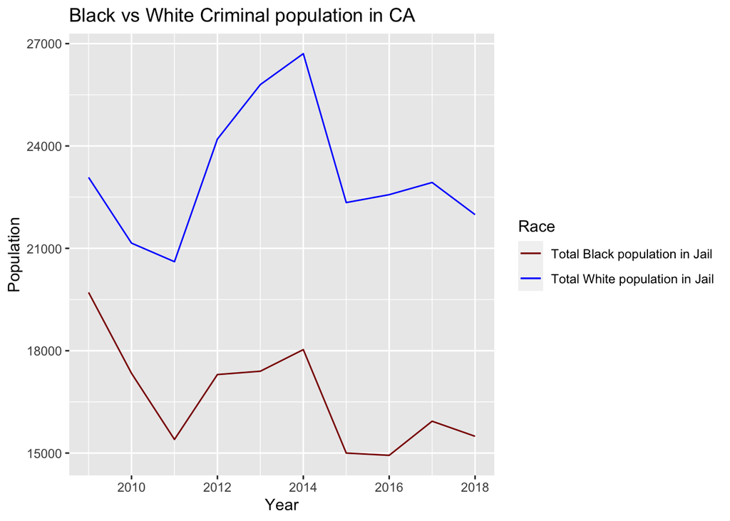

```r
plot(chart_1)
```

## Variable Comparison Chart

For the second chart, I find the Male Juvenile criminal population rate to see the difference ratio in a different state. In the graph, we can see WY has a very dark blue color, which means it has a lower male juvenile population rate. Compared with WY, CA has the lightest color of blue, and it indicates CA has a high percentage of the male juvenile population in the United States. This chart emerges the United States’ education system, which shows that states like CA and NJ need to put more effort into education policy and make sure less juvenile to be a criminal.

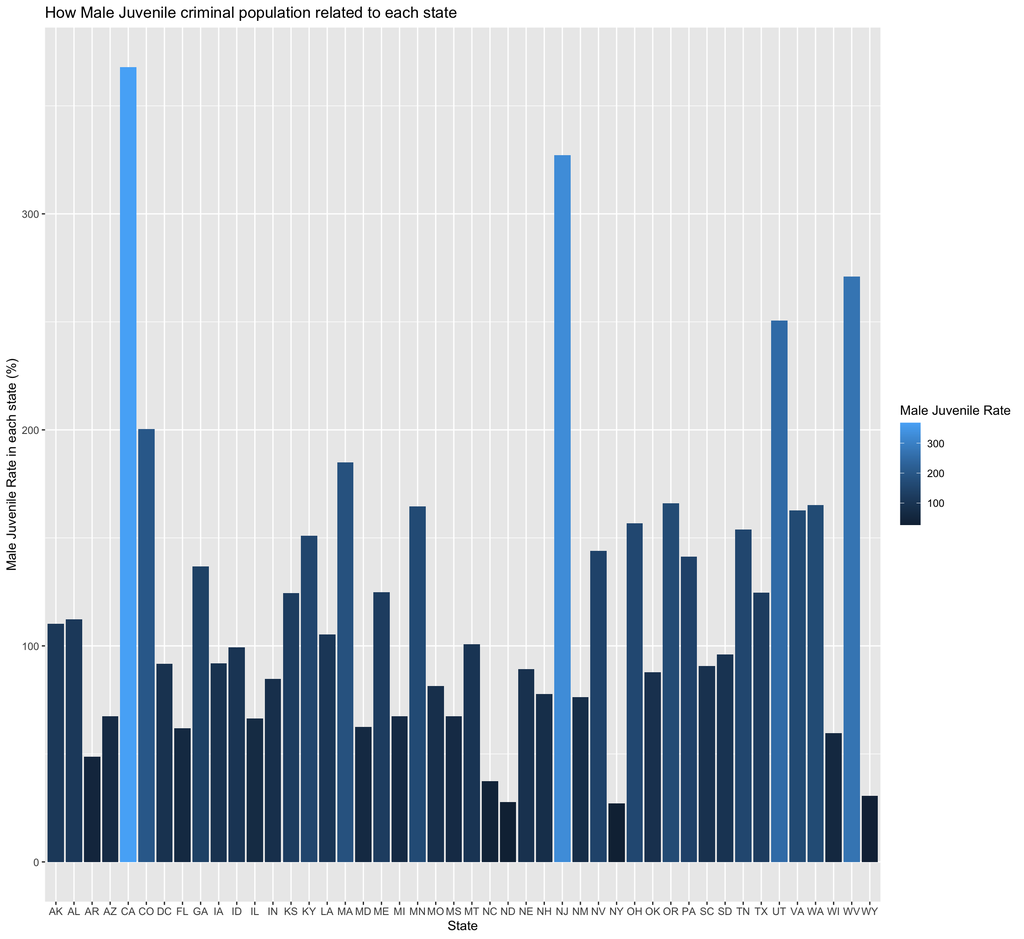

```r
plot(chart_2)
```

## Map

In the map, I create Asian American and Pacific Islander Jail population in NY to see how the AAPI population rate across New York. New York City has the highest Asian population in 2010, with more than 8 million people(Wikipedia). Then I want to create this map to see how the Asian American and Pacific Islander jail population is distributed in New York. New York City has the largest Asian community, so how does it relate to the AAPI jail population in NY? Will a specific county have a higher crime rate because of a large population of races living there? This map answers those questions, which emerges in the middle and north part of New York with a higher AAPI jail population than the south region.

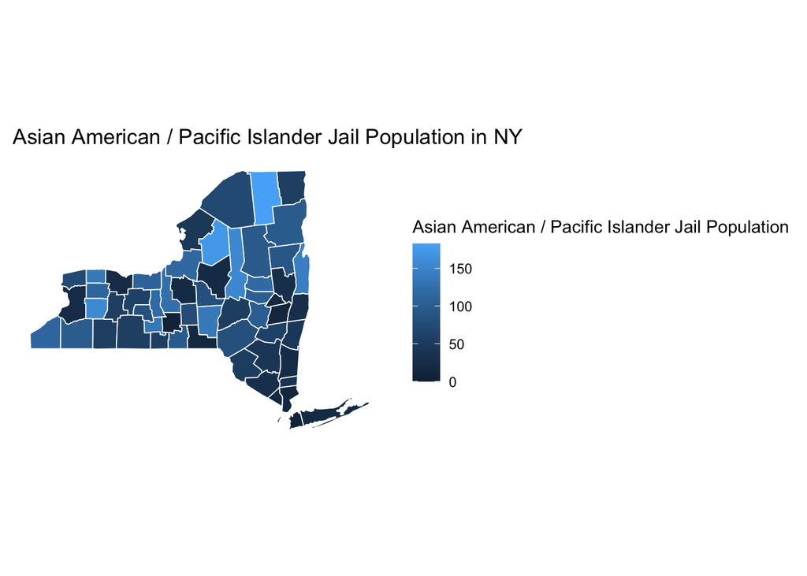

```r
plot(aapi_pop_ny)
```